# 2D simulated case study: Diagnosis of the HSGP approximation

Gabriel Riutort-Mayol

2022-05-15.

This notebook implements the HSGP model fit and diagnosis on the 2D dataset in case study 5.3 ‘*Simulated data for 2D and 3D functions*’ in [Riutort-Mayol, G., Bürkner, P. C., Andersen, M. R., Solin, A., & Vehtari, A. (2020; updated in 2022). Practical Hilbert space approximate Bayesian Gaussian processes for probabilistic programming. arXiv preprint arXiv:2004.11408.](https://arxiv.org/pdf/2004.11408.pdf)

# 1 Load packages

```r
library(rstan)
library(cmdstanr)
options(mc.cores = parallel::detectCores())
rstan_options(auto_write = FALSE)
library(posterior)
library(bayesplot)
library(RColorBrewer)
library(ggplot2)
```

# 2 Synthetic dataset

A synthetic dataset $\boldsymbol{y}$ with a true data generating function $f(\boldsymbol{x})$, with $\boldsymbol{x}_i \in {\rm I\!R}^2$, where $f(\boldsymbol{x})$ is a Gaussian process (GP) with a squared exponential kernel. Gaussian errors $\boldsymbol{\epsilon}$ are added to $f(\boldsymbol{x})$ to form the final synthetic noisy dataset $\boldsymbol{y}$.

$$\begin{align*}
\begin{split}
\boldsymbol{y} &= \boldsymbol{f} + \boldsymbol{\epsilon} \\
\boldsymbol{\epsilon} &\sim \text{Normal}(\boldsymbol{0}, \sigma^2 \boldsymbol{I}) \\
f(\boldsymbol{x}) &\sim \text{GP}(0, k(\boldsymbol{x}, \boldsymbol{x}', \theta)),
\end{split}
\end{align*}$$

where $k(\boldsymbol{x}, \boldsymbol{x}', \theta)$ is a squared exponential kernel as a function of input values $\boldsymbol{x}$ and parameters $\theta=(\alpha,\boldsymbol{\ell})$, where $\alpha$ is the marginal variance of the GP function and $\boldsymbol{\ell}=(\ell_1,\ell_2)$ the lengthscale of the kernel for dimensions 1 and 2, respectively.

## 2.1 Draw the true data generative function $f(x)$ from a GP

### 2.1.1 Input predictive space

Matrix of 2D-predictive input points `x_pred`

```r
x_pred <- expand.grid(x1= seq(-1,1,by=0.04), x2= seq(-1,1,by=0.04))
str(x_pred)
```

```
'data.frame':   2601 obs. of  2 variables:
 $ x1: num  -1 -0.96 -0.92 -0.88 -0.84 -0.8 -0.76 -0.72 -0.68 -0.64 ...
 $ x2: num  -1 -1 -1 -1 -1 -1 -1 -1 -1 -1 ...
 - attr(*, "out.attrs")=List of 2
  ..$ dim     : Named int [1:2] 51 51
  .. ..- attr(*, "names")= chr [1:2] "x1" "x2"
  ..$ dimnames:List of 2
  .. ..$ x1: chr [1:51] "x1=-1.00" "x1=-0.96" "x1=-0.92" "x1=-0.88" ...
  .. ..$ x2: chr [1:51] "x2=-1.00" "x2=-0.96" "x2=-0.92" "x2=-0.88" ...
```

Length of `x_pred` (`N_pred`)

```r
N_pred <- dim(x_pred)[1]
N_pred
```

```
[1] 2601
```

Number of dimensions `D`

```r
D <- 2
D
```

```
[1] 2
```

Half range `S` of every input dimension

```r
S1 <- abs((max(x_pred$x1) - min(x_pred$x1))/2)
S1
```

```
[1] 1
```

```r
S2 <- abs((max(x_pred$x2) - min(x_pred$x2))/2)
S2
```

```
[1] 1
```

### 2.1.2 Draw $f(x)$ using Stan

Marginal variance `gpscale` ($\alpha$) and multivariate lengthscale `lscale` ($\boldsymbol{\ell}$)

```r
gpscale <- 1.1
lscale <- vector()
lscale[1] <- 0.1
lscale[2] <- 0.3
```

Random variable `eta` to simulate from the GP

```r
seed <- 88646
set.seed(seed)
eta <- rnorm(N_pred, 0, 1)
```

Data to be passed to Stan

```r
standata <- list(D= D,
                 N_pred= N_pred,
                 x_pred= x_pred,
                 gpscale= gpscale,
                 lscale= lscale,
                 eta= eta)
```

Model sampling

```r
simuGP_mod <- cmdstanr::cmdstan_model(stan_file = "stancode_SIMU_2D.stan")
fit_SIMU <- simuGP_mod$sample(data= standata,
                                iter_warmup=1,
                                iter_sampling=1,
                                chains=1, thin=1, init=0.5,
                                fixed_param=TRUE)
fit_SIMU <- read_stan_csv(fit_SIMU$output_files())
```

Drawn $f(x)$

```r
f_true <- extract(fit_SIMU, pars="f_true", permuted = TRUE, inc_warmup = FALSE, include = TRUE)$f_true[1,]
```

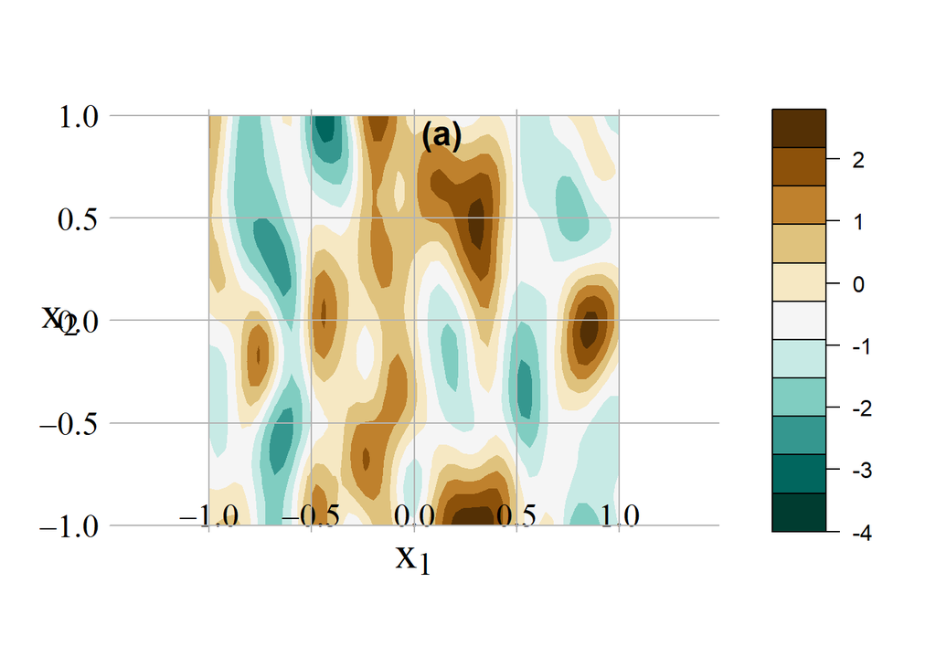

## 2.2 Adding noise to $f(x)$

```r
set.seed(1234)
y_pred <- f_true + rnorm(N_pred, 0, 0.2)
```

## 2.3 Sampling data set

```r
nobs <- 150
set.seed(4567)
vv_sample <- sample(1:N_pred, nobs)
N_sample <- length(vv_sample)
```

# 3 GP model fitting

## 3.1 Data

Data to Stan

```r
standata_GP <- list(D= D,
                    N_sample= N_sample,
                    vv_sample= vv_sample,
                    N_pred= N_pred,
                    x_pred= x_pred,
                    y_pred= y_pred)
str(standata_GP)
```

```
List of 6
 $ D        : num 2
 $ N_sample : int 150
 $ vv_sample: int [1:150] 2435 1792 144 2440 2039 522 205 2119 1391 1974 ...
 $ N_pred   : int 2601
 $ x_pred   :'data.frame':  2601 obs. of  2 variables:
  ..$ x1: num [1:2601] -1 -0.96 -0.92 -0.88 -0.84 -0.8 -0.76 -0.72 -0.68 -0.64 ...
  ..$ x2: num [1:2601] -1 -1 -1 -1 -1 -1 -1 -1 -1 -1 ...
  ..- attr(*, "out.attrs")=List of 2
  .. ..$ dim     : Named int [1:2] 51 51
  .. .. ..- attr(*, "names")= chr [1:2] "x1" "x2"
  .. ..$ dimnames:List of 2
  .. .. ..$ x1: chr [1:51] "x1=-1.00" "x1=-0.96" "x1=-0.92" "x1=-0.88" ...
  .. .. ..$ x2: chr [1:51] "x2=-1.00" "x2=-0.96" "x2=-0.92" "x2=-0.88" ...
 $ y_pred   : num [1:2601] 0.0357 0.4192 0.6664 0.018 0.387 ...
```

## 3.2 Model fitting

Model fitting

```r
GP_mod <- cmdstanr::cmdstan_model(stan_file = "stancode_GP_marginalized_2D.stan")
fit_GP <- GP_mod$sample(data= standata_GP,
                          iter_warmup=50,
                          iter_sampling=50,
                          chains=4, thin=1, init=2,
                          save_warmup=FALSE)
fit_GP <- read_stan_csv(fit_GP$output_files())
```

Summaries and simulation chains for the variables after warmup

```r
param = c("lscale","gpscale[1]","noise")
print(summary(fit_GP, pars = param, probs = c(0.025, 0.5, 0.975))$summary)
```

```
                mean      se_mean          sd       2.5%       50%     97.5%
lscale[1]  0.1038284 0.0007145208 0.009184816 0.08644849 0.1036035 0.1223649
lscale[2]  0.2925152 0.0016139018 0.023301978 0.24727195 0.2925350 0.3409867
gpscale[1] 1.1735839 0.0099267074 0.115019446 0.98627420 1.1651700 1.3893150
noise      0.1782457 0.0017556808 0.019367678 0.14371892 0.1786360 0.2117999
              n_eff     Rhat
lscale[1]  165.2384 1.018290
lscale[2]  208.4641 1.013994
gpscale[1] 134.2555 1.005593
noise      121.6926 1.014269
```

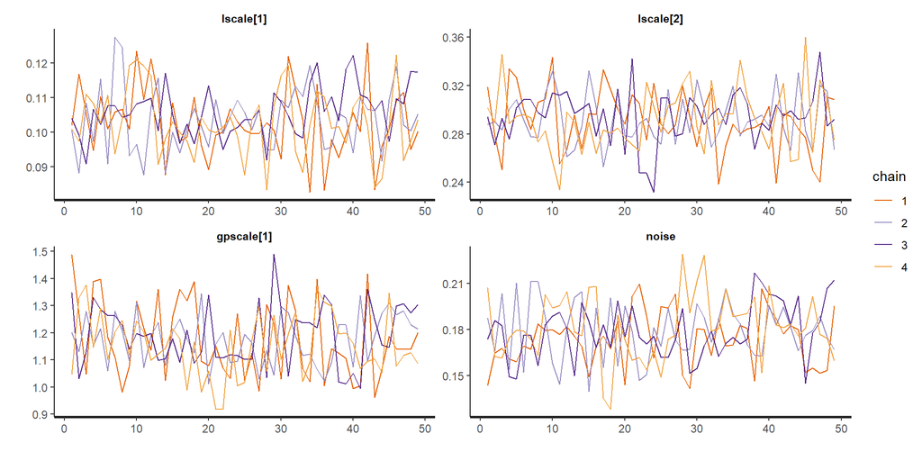

```r
traceplot(fit_GP, pars = param, include = TRUE, unconstrain = FALSE, inc_warmup = FALSE, window = NULL, nrow = NULL, ncol = NULL)
```

## 3.3 Posterior predictive distribution

```r
f_gp <- summary(fit_GP, pars = c("f_pred"), probs = c(0.025, 0.5, 0.975), digits_summary = 4)$summary[,c(1,4,6)]
```

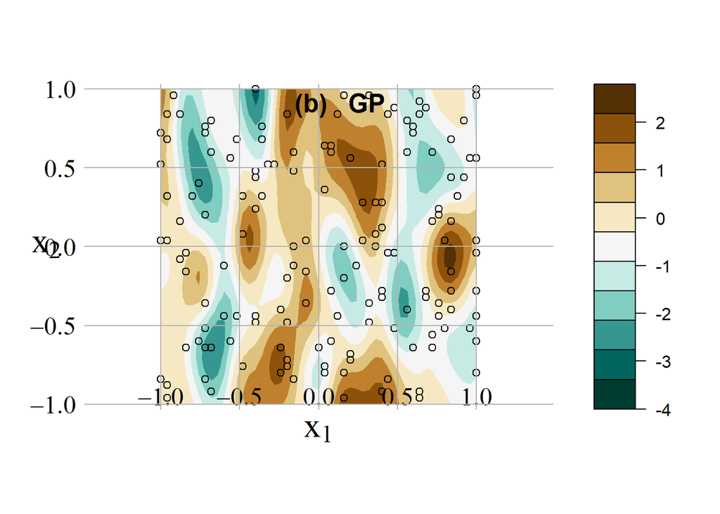

## 3.4 Error plot

```r
error <- f_true - f_gp[,1]
```

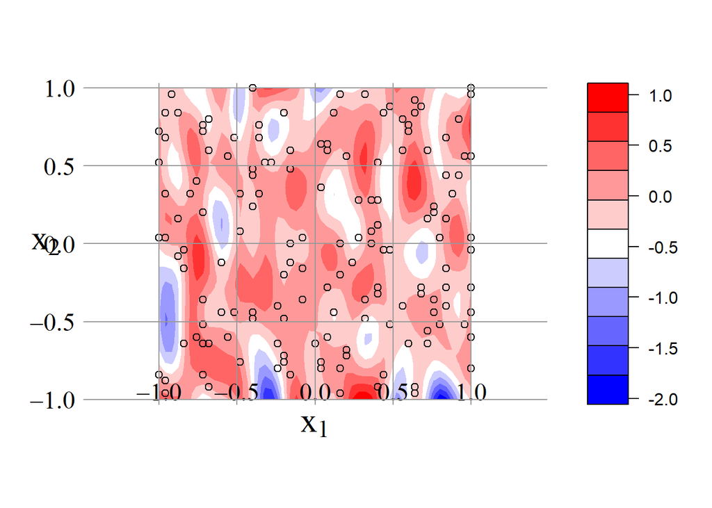

# 4 Functional relationships among $m$, $\ell$ and $c$ parameters in the HSGP approach

Relationship among the number of basis functions $m$, the lengthscale $\ell$ and the boundary factor $c$ for a **squared exponential kernel** in the HSGP approach:

$$\begin{align*}
m= 1.75 \frac{c}{\frac{\ell}{S}} \;\; \Leftrightarrow \;\; \frac{\ell}{S}= 1.75 \, \frac{c}{m} \tag{4.1}
\end{align*}$$

```r
m_QE <- function(c,l,S) ceiling(1.75 * c / (l/S))
l_QE <- function(c,m,S) round(S * 1.75 * c / m, 3)
```

as a function of $\ell$ and $S$, where $S$ is the half range of the input domain

```r
c_vs_l_QE <- function(l,S){
    c =  3.2*l/S
    if(c < 1.2)
      c = 1.2
  c
}
```

# 5 Lengthscale diagnostic

The HSGP lengthscale diagnostic is defined as:

$$\begin{align*}
\hat{\ell} + 0.01 \geq \ell \tag{5.1}
\end{align*}$$

```r
diagnostic <- function(l,l_hat) l_hat + 0.01 >= l
```

# 6 HSGP fit and diagnosis

Initializing programming objects

```r
standata <- list()
fit<- list()
diagnosis <- list()

l1 <- vector()  # lengthscale for dimension 1
l2 <- vector()  # lengthscale for dimension 2
c1 <- vector()  # boundary factor for dimension 1
c2 <- vector()  # boundary factor for dimension 2
m1 <- vector()  # number of basis functions for dimension 1
m2 <- vector()  # number of basis functions for dimension 2
l_hat1 <- vector()  # HSGP lengthscale estimate for dimension 1
l_hat2 <- vector()  # HSGP lengthscale estimate for dimension 2
check1 <- vector()  # Diagnostic for dimension 1
check2 <- vector()  # Diagnostic for dimension 2
rmse_gp <- vector()  # root mean square error of GP model
rmse <- vector()  # root mean square error of HSGP model
eR <- vector()  # coefficient of determination of HSGP model
elpd <- vector()  # expected log predictive density of HSGP model
```

## 6.1 Iteration 1

```r
i <- 1
print(paste("Iteration i =", i), quote = FALSE)
```

```
[1] Iteration i = 1
```

### 6.1.1 Setting $m$, $\ell$ and $c$

If iteration $i=1$:

1. Making a first guess for lengthscale $\ell_i$
2. The boundary factor $c_i$ has to fulfill equation (4.2)
3. The number of basis functions $m_i$ has to fulfill equation (4.1)

```r
if(i==1){
  l1[i] <- 0.5
  c1[i] <- c_vs_l_QE(l=l1[i], S=S1)
  m1[i] <- m_QE(c=c1[i], l=l1[i], S=S1)

  l2[i] <- 1
  c2[i] <- c_vs_l_QE(l=l2[i], S=S2)
  m2[i] <- m_QE(c=c2[i], l=l2[i], S=S2)
}
```

### 6.1.2 Matrix of $D$-tuples

Matrix of $D$-tuples as in equation (10) in the [paper](https://arxiv.org/pdf/2004.11408.pdf)

```r
indices <- matrix(NA, m1[i]*m2[i], D)
mm=0;
for (r in 1:m1[i]){
    for (s in 1:m2[i]){
        mm = mm+1
        indices[mm,] = c(r, s)
    }
}
```

### 6.1.3 Data to be passed to Stan

```r
standata[[i]] <- list(D= D,
                      M= c(m1[i], m2[i]),
                      M_nD= m1[i]*m2[i],
                      indices= indices,
                      L= c(c1[i], c2[i]) * c(S1, S2),
                      x_pred= x_pred,
                      y_pred= y_pred,
                      N_sample= N_sample,
                      N_pred= N_pred,
                      vv_sample= vv_sample
)
str(standata[[i]])
```

```
List of 10
 $ D        : num 2
 $ M        : num [1:2] 6 6
 $ M_nD     : num 36
 $ indices  : int [1:36, 1:2] 1 1 1 1 1 1 2 2 2 2 ...
 $ L        : num [1:2] 1.6 3.2
 $ x_pred   :'data.frame':  2601 obs. of  2 variables:
  ..$ x1: num [1:2601] -1 -0.96 -0.92 -0.88 -0.84 -0.8 -0.76 -0.72 -0.68 -0.64 ...
  ..$ x2: num [1:2601] -1 -1 -1 -1 -1 -1 -1 -1 -1 -1 ...
  ..- attr(*, "out.attrs")=List of 2
  .. ..$ dim     : Named int [1:2] 51 51
  .. .. ..- attr(*, "names")= chr [1:2] "x1" "x2"
  .. ..$ dimnames:List of 2
  .. .. ..$ x1: chr [1:51] "x1=-1.00" "x1=-0.96" "x1=-0.92" "x1=-0.88" ...
  .. .. ..$ x2: chr [1:51] "x2=-1.00" "x2=-0.96" "x2=-0.92" "x2=-0.88" ...
 $ y_pred   : num [1:2601] 0.0357 0.4192 0.6664 0.018 0.387 ...
 $ N_sample : int 150
 $ N_pred   : int 2601
 $ vv_sample: int [1:150] 2435 1792 144 2440 2039 522 205 2119 1391 1974 ...
```

### 6.1.4 Model fitting

Model fitting

```r
hsgp_mod <- cmdstanr::cmdstan_model(stan_file = "stancode_HSGP_2D.stan")
fit[[i]] <- hsgp_mod$sample(data= standata[[i]],
                                iter_warmup=100,
                                iter_sampling=100,
                                chains=4, thin=2, init=0.5,
                                # adapt_delta=0.9,
                                save_warmup=TRUE)
fit[[i]] <- rstan::read_stan_csv(fit[[i]]$output_files())
```

Summaries and simulation chains of variable estimates

```r
param = c("lscale[1]","lscale[2]","gpscale","noise")
summary(fit[[i]], pars = param, probs = c(0.025, 0.5, 0.975))$summary
```

```
               mean     se_mean         sd       2.5%       50%     97.5%
lscale[1] 0.1898598 0.005184544 0.07419170 0.07930867 0.1777365 0.3445573
lscale[2] 0.2509116 0.008758690 0.12672165 0.07760896 0.2259845 0.5435681
gpscale   2.3714210 0.052545560 0.75863810 1.30417950 2.2429100 3.8760925
noise     0.8119479 0.003409841 0.05102247 0.72401030 0.8155165 0.9231324
             n_eff      Rhat
lscale[1] 204.7809 1.0059599
lscale[2] 209.3261 0.9924126
gpscale   208.4478 1.0101682
noise     223.9003 0.9943943
```

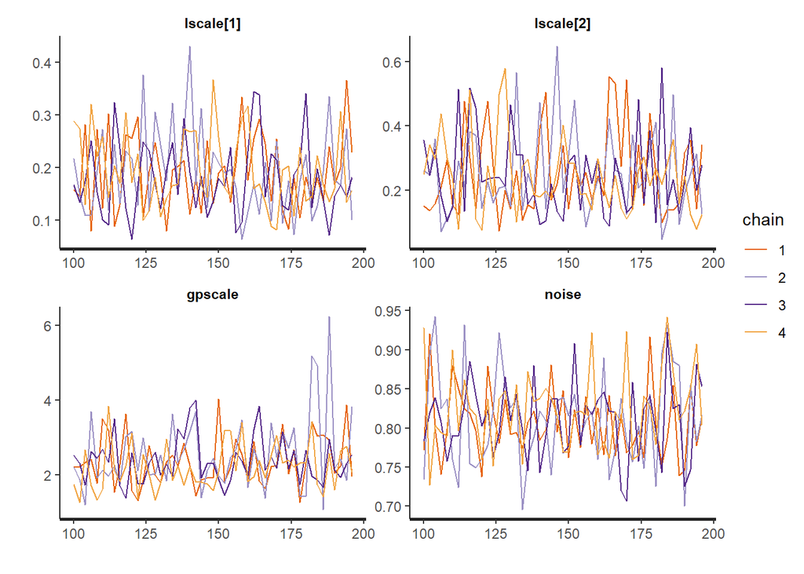

```r
traceplot(fit[[i]], pars = param, include = TRUE, unconstrain = FALSE, inc_warmup = FALSE, window = NULL, nrow = NULL, ncol = NULL)
```

### 6.1.5 Model evaluation

Root mean square error `rmse`, Bayesian $R^2$ (Coefficient of determination) `eR`, and expected log predictive density `elpd`.

```r
f_hsgp <- summary(fit[[i]], pars = c("f"), probs = c(0.025, 0.5, 0.975), digits_summary = 4)$summary[,c(1,4,6)]

# rmse against data
residual <- standata[[i]]$y_pred[vv_sample] - f_hsgp[,1]
rmse[i] <- round(sqrt(mean(residual^2)), 2)

# rmse against gp
residual_gp <- f_gp[vv_sample] - f_hsgp[,1]
rmse_gp[i] <- round(sqrt(mean(residual_gp^2)), 2)

# Coefficient of determination R^2
noise <- as.matrix(fit[[i]], pars = c("noise"))
sd_f <- apply(as.matrix(fit[[i]], pars = c("f")), 1, sd)
eR[i] <- round(median(sd_f^2/(sd_f^2 + noise^2)), 2)

# elpd
elpd[i] <- round(median(summary(fit[[i]], pars = c("elpd"))$summary[,1]), 2)
```

### 6.1.6 Diagnosis

Lengthscale estimate $\hat{\ell}_i$ in the HSGP approximation

```r
l_hat1[i] <- round(summary(fit[[i]], pars = "lscale[1]", probs = c(0.05, 0.95))$summary[,1], 2)
l_hat2[i] <- round(summary(fit[[i]], pars = "lscale[2]", probs = c(0.05, 0.95))$summary[,1], 2)
```

Check the diagnostic of whether $\, \hat{\ell}_i + 0.01 \geq \ell_i$ (5.1)

```r
check1[i] <- diagnostic(l1[i], l_hat1[i])
check2[i] <- diagnostic(l2[i], l_hat2[i])
```

Summary table of diagnosis

```r
diagnosis[[i]] <- data.frame(iter= c(i, i),
                              Dim= c("D1", "D2"),
                              l= c(l1[i], l2[i]),
                              c= c(c1[i], c2[i]),
                              m= c(m1[i], m2[i]),
                              l_hat= c(l_hat1[i], l_hat2[i]),
                              'l_hat > l' = c(check1[i], check2[i]),
                              rsme_gp = c(NA, rmse_gp[i]),
                              rsme = c(NA, rmse[i]),
                              R2 = c(NA, eR[i]),
                              elpd = c(NA, elpd[i]))
names(diagnosis[[i]]) <- c("iter", "Dim", "l", "c", "m", "l_hat", "l_hat + 0.01 > l", "rmse_gp", "rmse", "R^2", "elpd")

if(i==1){
  diagnosis[[i]]
}else{
  diagnosis[[i]] <- rbind(diagnosis[[i-1]],diagnosis[[i]])
  diagnosis[[i]]
}
```

| iter | Dim | l | c | m | l_hat | l_hat + 0.01 > l | rmse_gp | rmse | R^2 | elpd |
| --- | --- | --- | --- | --- | --- | --- | --- | --- | --- | --- |
| 1 | D1 | 0.5 | 1.6 | 6 | 0.19 | FALSE | NA | NA | NA | NA |
| 1 | D2 | 1.0 | 3.2 | 6 | 0.25 | FALSE | 0.72 | 0.75 | 0.46 | -0.96 |

## 6.2 Iteration 2

```r
i <- 2
print(paste("Iteration i =", i), quote = FALSE)
```

```
[1] Iteration i = 2
```

### 6.2.1 Setting $m$, $\ell$ and $c$

If the diagnostic $\hat{\ell}_{i-1} + 0.01 \geq \ell_{i-1}$ (5.1) is TRUE and iteration $i=2$:

1. Update $m_i = m_{i-1} + 2$
2. The boundary factor $c_i$ has to fulfill (4.2) where $c(\cdot)$ is evaluated as a function of $\hat{\ell}_{i-1}$
3. The lengthscale $\ell_i$ has to fulfill (4.1)

```r
if(diagnostic(l1[i-1], l_hat1[i-1]) & i==2){
  m1[i] <- m1[i-1] + 2
  c1[i] <- c_vs_l_QE(l=l_hat1[i-1], S=S1)
  l1[i] <- l_QE(c=c1[i], m=m1[i], S=S1)
}

if(diagnostic(l2[i-1], l_hat2[i-1]) & i==2){
  m2[i] <- m2[i-1] + 2
  c2[i] <- c_vs_l_QE(l=l_hat2[i-1], S=S2)
  l2[i] <- l_QE(c=c2[i], m=m2[i], S=S2)
}
```

If the diagnostic $\hat{\ell}_{i-1} + 0.01 \geq \ell_{i-1}$ (5.1) is FALSE:

1. Update $\ell_i = \hat{\ell}_{i-1}$
2. The boundary factor $c_i$ has to fulfill (4.2)
3. The number of basis functions $m_i$ as a function of $\ell_i$ and $c_i$ by using (4.1)

```r
if(!diagnostic(l1[i-1], l_hat1[i-1])){
  l1[i] <- l_hat1[i-1]
  c1[i] <- c_vs_l_QE(l=l1[i], S=S1)
  m1[i] <- m_QE(c=c1[i], l=l1[i], S=S1)
}

if(!diagnostic(l2[i-1], l_hat2[i-1])){
  l2[i] <- l_hat2[i-1]
  c2[i] <- c_vs_l_QE(l=l2[i], S=S2)
  m2[i] <- m_QE(c=c2[i], l=l2[i], S=S2)
}
```

### 6.2.2 Matrix of $D$-tuples

Matrix of $D$-tuples as in equation (10) in the [paper](https://arxiv.org/pdf/2004.11408.pdf)

```r
indices <- matrix(NA, m1[i]*m2[i], D)
mm=0;
for (r in 1:m1[i]){
    for (s in 1:m2[i]){
            mm = mm+1
            indices[mm,] = c(r, s)
    }
}
```

### 6.2.3 Data to be passed to Stan

```r
standata[[i]] <- list(D= D,
                      M= c(m1[i], m2[i]),
                      M_nD= m1[i]*m2[i],
                      indices= indices,
                      L= c(c1[i], c2[i]) * c(S1, S2),
                      x_pred= x_pred,
                      y_pred= y_pred,
                      N_sample= N_sample,
                      N_pred= N_pred,
                      vv_sample= vv_sample
)
str(standata[[i]])
```

```
List of 10
 $ D        : num 2
 $ M        : num [1:2] 12 9
 $ M_nD     : num 108
 $ indices  : int [1:108, 1:2] 1 1 1 1 1 1 1 1 1 2 ...
 $ L        : num [1:2] 1.2 1.2
 $ x_pred   :'data.frame':  2601 obs. of  2 variables:
  ..$ x1: num [1:2601] -1 -0.96 -0.92 -0.88 -0.84 -0.8 -0.76 -0.72 -0.68 -0.64 ...
  ..$ x2: num [1:2601] -1 -1 -1 -1 -1 -1 -1 -1 -1 -1 ...
  ..- attr(*, "out.attrs")=List of 2
  .. ..$ dim     : Named int [1:2] 51 51
  .. .. ..- attr(*, "names")= chr [1:2] "x1" "x2"
  .. ..$ dimnames:List of 2
  .. .. ..$ x1: chr [1:51] "x1=-1.00" "x1=-0.96" "x1=-0.92" "x1=-0.88" ...
  .. .. ..$ x2: chr [1:51] "x2=-1.00" "x2=-0.96" "x2=-0.92" "x2=-0.88" ...
 $ y_pred   : num [1:2601] 0.0357 0.4192 0.6664 0.018 0.387 ...
 $ N_sample : int 150
 $ N_pred   : int 2601
 $ vv_sample: int [1:150] 2435 1792 144 2440 2039 522 205 2119 1391 1974 ...
```

### 6.2.4 Model fitting

Model fitting

```r
hsgp_mod <- cmdstanr::cmdstan_model(stan_file = "stancode_HSGP_2D.stan")
fit[[i]] <- hsgp_mod$sample(data= standata[[i]],
                                iter_warmup=100,
                                iter_sampling=100,
                                chains=4, thin=2, init=0.5,
                                # adapt_delta=0.9,
                                save_warmup=TRUE)
fit[[i]] <- rstan::read_stan_csv(fit[[i]]$output_files())
```

Summaries and simulation chains of variable estimates

```r
param = c("lscale[1]","lscale[2]","gpscale","noise")
summary(fit[[i]], pars = param, probs = c(0.025, 0.5, 0.975))$summary
```

```
               mean     se_mean         sd      2.5%       50%     97.5%
lscale[1] 0.1073860 0.001507670 0.01973684 0.0632864 0.1095645 0.1388240
lscale[2] 0.2531847 0.001685293 0.02164917 0.2141497 0.2550600 0.2941297
gpscale   1.3590385 0.011323846 0.14415458 1.1134110 1.3572900 1.6986725
noise     0.2620099 0.002414801 0.02254159 0.2188541 0.2610700 0.3097639
              n_eff      Rhat
lscale[1] 171.37317 1.0065419
lscale[2] 165.01819 1.0132198
gpscale   162.05744 1.0032114
noise      87.13776 0.9994386
```

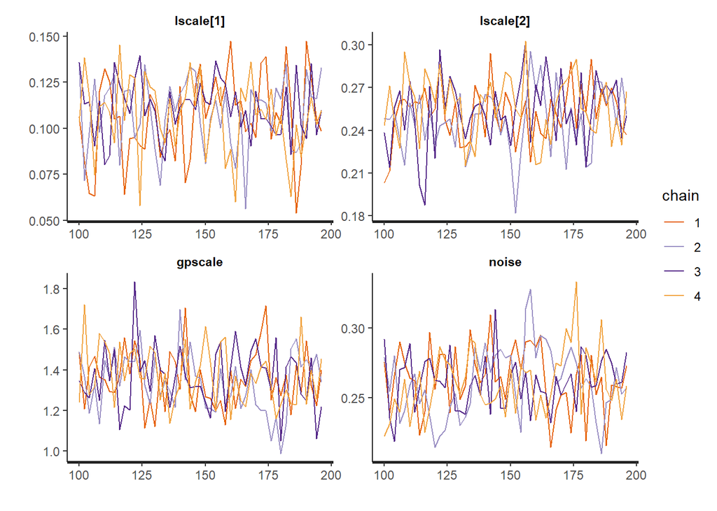

```r
traceplot(fit[[i]], pars = param, include = TRUE, unconstrain = FALSE, inc_warmup = FALSE, window = NULL, nrow = NULL, ncol = NULL)
```

### 6.2.5 Model evaluation

Root mean square error `rmse`, Bayesian $R^2$ (Coefficient of determination) `eR`, and expected log predictive density `elpd`.

```r
f_hsgp <- summary(fit[[i]], pars = c("f"), probs = c(0.025, 0.5, 0.975), digits_summary = 4)$summary[,c(1,4,6)]

# rmse against data
residual <- standata[[i]]$y_pred[vv_sample] - f_hsgp[,1]
rmse[i] <- round(sqrt(mean(residual^2)), 2)

# rmse against gp
residual_gp <- f_gp[vv_sample] - f_hsgp[,1]
rmse_gp[i] <- round(sqrt(mean(residual_gp^2)), 2)

# Coefficient of determination R^2
noise <- as.matrix(fit[[i]], pars = c("noise"))
sd_f <- apply(as.matrix(fit[[i]], pars = c("f")), 1, sd)
eR[i] <- round(median(sd_f^2/(sd_f^2 + noise^2)), 2)

# elpd
elpd[i] <- round(median(summary(fit[[i]], pars = c("elpd"))$summary[,1]), 2)
```

### 6.2.6 Diagnosis

Lengthscale estimate $\hat{\ell_i}$ in the HSGP approximation

```r
l_hat1[i] <- round(summary(fit[[i]], pars = "lscale[1]", probs = c(0.05, 0.95))$summary[,1], 3)
l_hat2[i] <- round(summary(fit[[i]], pars = "lscale[2]", probs = c(0.05, 0.95))$summary[,1], 3)
```

Check the diagnostic of whether $\, \hat{\ell_i} + 0.01 \geq \ell_i$ (5.1)

```r
check1[i] <- diagnostic(l1[i], l_hat1[i])
check2[i] <- diagnostic(l2[i], l_hat2[i])
```

Summary table of diagnosis

```r
diagnosis[[i]] <- data.frame(iter= c(i, i),
                              Dim= c("D1", "D2"),
                              l= c(l1[i], l2[i]),
                              c= c(c1[i], c2[i]),
                              m= c(m1[i], m2[i]),
                              l_hat= c(l_hat1[i], l_hat2[i]),
                              'l_hat > l' = c(check1[i], check2[i]),
                              rsme_gp = c(NA, rmse_gp[i]),
                              rsme = c(NA, rmse[i]),
                              R2 = c(NA, eR[i]),
                              elpd = c(NA, elpd[i]))
names(diagnosis[[i]]) <- c("iter", "Dim", "l", "c", "m", "l_hat", "l_hat + 0.01 > l", "rmse_gp", "rmse", "R^2", "elpd")

if(i==1){
  diagnosis[[i]]
}else{
  diagnosis[[i]] <- rbind(diagnosis[[i-1]],diagnosis[[i]])
  diagnosis[[i]]
}
```

| iter | Dim | l | c | m | l_hat | l_hat + 0.01 > l | rmse_gp | rmse | R^2 | elpd |
| --- | --- | --- | --- | --- | --- | --- | --- | --- | --- | --- |
| 1 | D1 | 0.50 | 1.6 | 6 | 0.190 | FALSE | NA | NA | NA | NA |
| 1 | D2 | 1.00 | 3.2 | 6 | 0.250 | FALSE | 0.72 | 0.75 | 0.46 | -0.96 |
| 2 | D1 | 0.19 | 1.2 | 12 | 0.107 | FALSE | NA | NA | NA | NA |
| 2 | D2 | 0.25 | 1.2 | 9 | 0.253 | TRUE | 0.12 | 0.18 | 0.94 | 0.04 |

## 6.3 Iteration 3

```r
i <- 3
print(paste("Iteration i =", i), quote = FALSE)
```

```
[1] Iteration i = 3
```

### 6.3.1 Setting $m$, $\ell$ and $c$

If the diagnostic $\hat{\ell}_{i-1} + 0.01 \geq \ell_{i-1}$ (5.1) is TRUE and iteration $i>2$ and diagnostic $\hat{\ell}_{i-2} + 0.01 \geq \ell_{i-2}$ (5.1) is FALSE:

1. Update $m_i = m_{i-1} + 2$
2. The boundary factor $c_i$ has to fulfill (4.2) where $c(\cdot)$ is evaluated as a function of $\hat{\ell}_{i-1}$
3. The lengthscale $\ell_i$ has to fulfill (4.1)

```r
if(diagnostic(l1[i-1], l_hat1[i-1]) & i>2 & !diagnostic(l1[i-2], l_hat1[i-2])){
  m1[i] <- m1[i-1] + 2
  c1[i] <- c_vs_l_QE(l=l_hat1[i-1], S=S1)
  l1[i] <- l_QE(c=c1[i], m=m1[i], S=S1)
}

if(diagnostic(l2[i-1], l_hat2[i-1]) & i>2 & !diagnostic(l2[i-2], l_hat2[i-2])){
  m2[i] <- m2[i-1] + 2
  c2[i] <- c_vs_l_QE(l=l_hat2[i-1], S=S2)
  l2[i] <- l_QE(c=c2[i], m=m2[i], S=S2)
}
```

If the diagnostic $\hat{\ell}_{i-1} + 0.01 \geq \ell_{i-1}$ (5.1) is TRUE and iteration $i>2$ and diagnostic $\hat{\ell}_{i-2} + 0.01 \geq \ell_{i-2}$ (5.1) is TRUE:

1. Update $m_i = m_{i-1}$
2. Update $c_i = c_{i-1}$
3. Update $\ell_i = \ell_{i-1}$

```r
if(diagnostic(l1[i-1], l_hat1[i-1]) & i>2 & diagnostic(l1[i-2], l_hat1[i-2])){
  m1[i] <- m1[i-1]
  c1[i] <- c1[i-1]
  l1[i] <- l1[i-1]
}

if(diagnostic(l2[i-1], l_hat2[i-1]) & i>2 & diagnostic(l2[i-2], l_hat2[i-2])){
  m2[i] <- m2[i-1]
  c2[i] <- c2[i-1]
  l2[i] <- l2[i-1]
}
```

If the diagnostic $\hat{\ell}_{i-1} + 0.01 \geq \ell_{i-1}$ (5.1) is FALSE:

1. Update $\ell_i = \hat{\ell}_{i-1}$
2. The boundary factor $c_i$ has to fulfill (4.2)
3. The number of basis functions $m_i$ as a function of $\ell_i$ and $c_i$ by using (4.1)

```r
if(!diagnostic(l1[i-1], l_hat1[i-1])){
  l1[i] <- l_hat1[i-1]
  c1[i] <- c_vs_l_QE(l=l1[i], S=S1)
  m1[i] <- m_QE(c=c1[i], l=l1[i], S=S1)
}

if(!diagnostic(l2[i-1], l_hat2[i-1])){
  l2[i] <- l_hat2[i-1]
  c2[i] <- c_vs_l_QE(l=l2[i], S=S2)
  m2[i] <- m_QE(c=c2[i], l=l2[i], S=S2)
}
```

### 6.3.2 Matrix of $D$-tuples

Matrix of $D$-tuples as in equation (10) in the [paper](https://arxiv.org/pdf/2004.11408.pdf)

```r
indices <- matrix(NA, m1[i]*m2[i], D)
mm=0;
for (r in 1:m1[i]){
    for (s in 1:m2[i]){
            mm = mm+1
            indices[mm,] = c(r, s)
    }
}
```

### 6.3.3 Data to be passed to Stan

```r
standata[[i]] <- list(D= D,
                      M= c(m1[i], m2[i]),
                      M_nD= m1[i]*m2[i],
                      indices= indices,
                      L= c(c1[i], c2[i]) * c(S1, S2),
                      x_pred= x_pred,
                      y_pred= y_pred,
                      N_sample= N_sample,
                      N_pred= N_pred,
                      vv_sample= vv_sample
)
str(standata[[i]])
```

```
List of 10
 $ D        : num 2
 $ M        : num [1:2] 20 11
 $ M_nD     : num 220
 $ indices  : int [1:220, 1:2] 1 1 1 1 1 1 1 1 1 1 ...
 $ L        : num [1:2] 1.2 1.2
 $ x_pred   :'data.frame':  2601 obs. of  2 variables:
  ..$ x1: num [1:2601] -1 -0.96 -0.92 -0.88 -0.84 -0.8 -0.76 -0.72 -0.68 -0.64 ...
  ..$ x2: num [1:2601] -1 -1 -1 -1 -1 -1 -1 -1 -1 -1 ...
  ..- attr(*, "out.attrs")=List of 2
  .. ..$ dim     : Named int [1:2] 51 51
  .. .. ..- attr(*, "names")= chr [1:2] "x1" "x2"
  .. ..$ dimnames:List of 2
  .. .. ..$ x1: chr [1:51] "x1=-1.00" "x1=-0.96" "x1=-0.92" "x1=-0.88" ...
  .. .. ..$ x2: chr [1:51] "x2=-1.00" "x2=-0.96" "x2=-0.92" "x2=-0.88" ...
 $ y_pred   : num [1:2601] 0.0357 0.4192 0.6664 0.018 0.387 ...
 $ N_sample : int 150
 $ N_pred   : int 2601
 $ vv_sample: int [1:150] 2435 1792 144 2440 2039 522 205 2119 1391 1974 ...
```

### 6.3.4 Model fitting

Model fitting

```r
hsgp_mod <- cmdstanr::cmdstan_model(stan_file = "stancode_HSGP_2D.stan")
fit[[i]] <- hsgp_mod$sample(data= standata[[i]],
                                iter_warmup=100,
                                iter_sampling=100,
                                chains=4, thin=2, init=0.5,
                                # adapt_delta=0.9,
                                save_warmup=TRUE)
fit[[i]] <- rstan::read_stan_csv(fit[[i]]$output_files())
```

Summaries and simulation chains of variable estimates

```r
param = c("lscale[1]","lscale[2]","gpscale","noise")
summary(fit[[i]], pars = param, probs = c(0.025, 0.5, 0.975))$summary
```

```
               mean     se_mean         sd       2.5%       50%     97.5%
lscale[1] 0.1043777 0.001040604 0.01207964 0.08175381 0.1041535 0.1290511
lscale[2] 0.2704200 0.001726412 0.02078291 0.23244172 0.2695120 0.3116284
gpscale   1.2012557 0.012776373 0.12372196 1.00113102 1.1957900 1.4798395
noise     0.1877091 0.003162951 0.02165127 0.15058140 0.1861085 0.2336842
              n_eff     Rhat
lscale[1] 134.75253 1.011421
lscale[2] 144.91851 1.000551
gpscale    93.77313 1.053706
noise      46.85776 1.086957
```

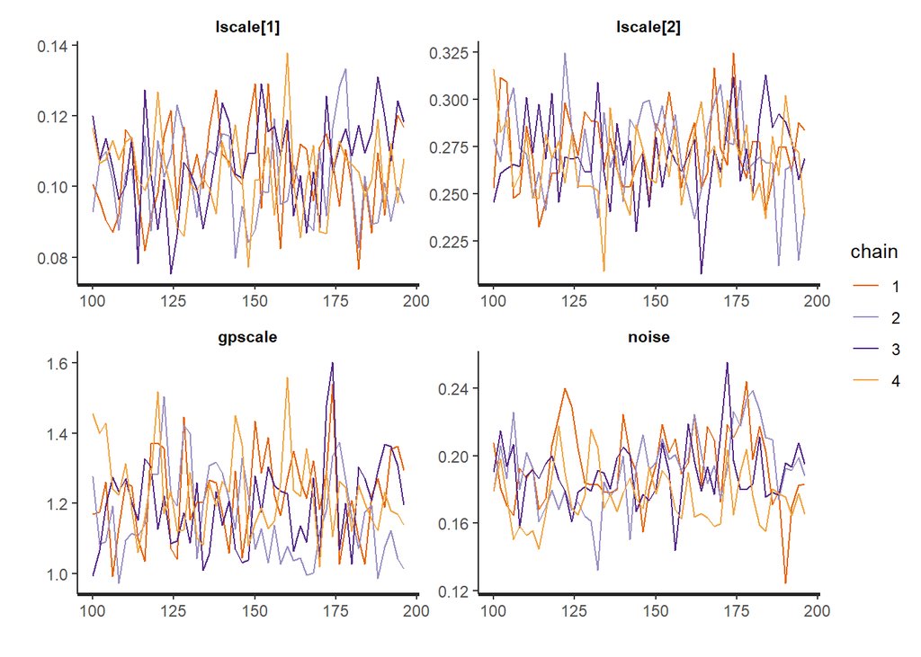

```r
traceplot(fit[[i]], pars = param, include = TRUE, unconstrain = FALSE, inc_warmup = FALSE, window = NULL, nrow = NULL, ncol = NULL)
```

### 6.3.5 Model evaluation

Root mean square error `rmse`, Bayesian $R^2$ (Coefficient of determination) `eR`, and expected log predictive density `elpd`.

```r
f_hsgp <- summary(fit[[i]], pars = c("f"), probs = c(0.025, 0.5, 0.975), digits_summary = 4)$summary[,c(1,4,6)]

# rmse against data
residual <- standata[[i]]$y_pred[vv_sample] - f_hsgp[,1]
rmse[i] <- round(sqrt(mean(residual^2)), 2)

# rmse against gp
residual_gp <- f_gp[vv_sample] - f_hsgp[,1]
rmse_gp[i] <- round(sqrt(mean(residual_gp^2)), 2)

# Coefficient of determination R^2
noise <- as.matrix(fit[[i]], pars = c("noise"))
sd_f <- apply(as.matrix(fit[[i]], pars = c("f")), 1, sd)
eR[i] <- round(median(sd_f^2/(sd_f^2 + noise^2)), 2)

# elpd
elpd[i] <- round(median(summary(fit[[i]], pars = c("elpd"))$summary[,1]), 2)
```

### 6.3.6 Diagnosis

Lengthscale estimate $\hat{\ell_i}$ in the HSGP approximation

```r
l_hat1[i] <- round(summary(fit[[i]], pars = "lscale[1]", probs = c(0.05, 0.95))$summary[,1], 2)
l_hat2[i] <- round(summary(fit[[i]], pars = "lscale[2]", probs = c(0.05, 0.95))$summary[,1], 2)
```

Check the diagnostic of whether $\, \hat{\ell_i} + 0.01 \geq \ell_i$ (5.1)

```r
check1[i] <- diagnostic(l1[i], l_hat1[i])
check2[i] <- diagnostic(l2[i], l_hat2[i])
```

Summary table of diagnosis

```r
diagnosis[[i]] <- data.frame(iter= c(i, i),
                              Dim= c("D1", "D2"),
                              l= c(l1[i], l2[i]),
                              c= c(c1[i], c2[i]),
                              m= c(m1[i], m2[i]),
                              l_hat= c(l_hat1[i], l_hat2[i]),
                              'l_hat > l' = c(check1[i], check2[i]),
                              rsme_gp = c(NA, rmse_gp[i]),
                              rsme = c(NA, rmse[i]),
                              R2 = c(NA, eR[i]),
                              elpd = c(NA, elpd[i]))
names(diagnosis[[i]]) <- c("iter", "Dim", "l", "c", "m", "l_hat", "l_hat + 0.01 > l", "rmse_gp", "rmse", "R^2", "elpd")

if(i==1){
  diagnosis[[i]]
}else{
  diagnosis[[i]] <- rbind(diagnosis[[i-1]],diagnosis[[i]])
  diagnosis[[i]]
}
```

| iter | Dim | l | c | m | l_hat | l_hat + 0.01 > l | rmse_gp | rmse | R^2 | elpd |
| --- | --- | --- | --- | --- | --- | --- | --- | --- | --- | --- |
| 1 | D1 | 0.500 | 1.6 | 6 | 0.190 | FALSE | NA | NA | NA | NA |
| 1 | D2 | 1.000 | 3.2 | 6 | 0.250 | FALSE | 0.72 | 0.75 | 0.46 | -0.96 |
| 2 | D1 | 0.190 | 1.2 | 12 | 0.107 | FALSE | NA | NA | NA | NA |
| 2 | D2 | 0.250 | 1.2 | 9 | 0.253 | TRUE | 0.12 | 0.18 | 0.94 | 0.04 |
| 3 | D1 | 0.107 | 1.2 | 20 | 0.100 | TRUE | NA | NA | NA | NA |
| 3 | D2 | 0.191 | 1.2 | 11 | 0.270 | TRUE | 0.03 | 0.11 | 0.97 | 0.31 |

## 6.4 Iteration 4

```r
i <- 4
print(paste("Iteration i =", i), quote = FALSE)
```

```
[1] Iteration i = 4
```

### 6.4.1 Setting $m$, $\ell$ and $c$

If the diagnostic $\hat{\ell}_{i-1} + 0.01 \geq \ell_{i-1}$ (5.1) is TRUE and iteration $i>2$ and diagnostic $\hat{\ell}_{i-2} \geq \ell_{i-2}$ (5.1) is FALSE:

1. Update $m_i = m_{i-1} + 2$
2. The boundary factor $c_i$ has to fulfill (4.2) where $c(\cdot)$ is evaluated as a function of $\hat{\ell}_{i-1}$
3. The lengthscale $\ell_i$ has to fulfill (4.1)

```r
if(diagnostic(l1[i-1], l_hat1[i-1]) & i>2 & !diagnostic(l1[i-2], l_hat1[i-2])){
  m1[i] <- m1[i-1] + 2
  c1[i] <- c_vs_l_QE(l=l_hat1[i-1], S=S1)
  l1[i] <- l_QE(c=c1[i], m=m1[i], S=S1)
}

if(diagnostic(l2[i-1], l_hat2[i-1]) & i>2 & !diagnostic(l2[i-2], l_hat2[i-2])){
  m2[i] <- m2[i-1] + 2
  c2[i] <- c_vs_l_QE(l=l_hat2[i-1], S=S2)
  l2[i] <- l_QE(c=c2[i], m=m2[i], S=S2)
}
```

If the diagnostic $\hat{\ell}_{i-1} + 0.01 \geq \ell_{i-1}$ (5.1) is TRUE and iteration $i>2$ and diagnostic $\hat{\ell}_{i-2} + 0.01 \geq \ell_{i-2}$ (5.1) is TRUE:

1. Update $m_i = m_{i-1}$
2. Update $c_i = c_{i-1}$
3. Update $\ell_i = \ell_{i-1}$

```r
if(diagnostic(l1[i-1], l_hat1[i-1]) & i>2 & diagnostic(l1[i-2], l_hat1[i-2])){
  m1[i] <- m1[i-1]
  c1[i] <- c1[i-1]
  l1[i] <- l1[i-1]
}

if(diagnostic(l2[i-1], l_hat2[i-1]) & i>2 & diagnostic(l2[i-2], l_hat2[i-2])){
  m2[i] <- m2[i-1]
  c2[i] <- c2[i-1]
  l2[i] <- l2[i-1]
}
```

If the diagnostic $\hat{\ell}_{i-1} + 0.01 \geq \ell_{i-1}$ (5.1) is FALSE:

1. Update $\ell_i = \hat{\ell}_{i-1}$
2. The boundary factor $c_i$ has to fulfill (4.2)
3. The number of basis functions $m_i$ as a function of $\ell_i$ and $c_i$ by using (4.1)

```r
if(!diagnostic(l1[i-1], l_hat1[i-1])){
  l1[i] <- l_hat1[i-1]
  c1[i] <- c_vs_l_QE(l=l1[i], S=S1)
  m1[i] <- m_QE(c=c1[i], l=l1[i], S=S1)
}

if(!diagnostic(l2[i-1], l_hat2[i-1])){
  l2[i] <- l_hat2[i-1]
  c2[i] <- c_vs_l_QE(l=l2[i], S=S2)
  m2[i] <- m_QE(c=c2[i], l=l2[i], S=S2)
}
```

### 6.4.2 Matrix of $D$-tuples

Matrix of $D$-tuples as in equation (10) in the [paper](https://arxiv.org/pdf/2004.11408.pdf)

```r
indices <- matrix(NA, m1[i]*m2[i], D)
mm=0;
for (r in 1:m1[i]){
    for (s in 1:m2[i]){
            mm = mm+1
            indices[mm,] = c(r, s)
    }
}
```

### 6.4.3 Data to be passed to Stan

```r
standata[[i]] <- list(D= D,
                      M= c(m1[i], m2[i]),
                      M_nD= m1[i]*m2[i],
                      indices= indices,
                      L= c(c1[i], c2[i]) * c(S1, S2),
                      x_pred= x_pred,
                      y_pred= y_pred,
                      N_sample= N_sample,
                      N_pred= N_pred,
                      vv_sample= vv_sample
)
str(standata[[i]])
```

```
List of 10
 $ D        : num 2
 $ M        : num [1:2] 22 11
 $ M_nD     : num 242
 $ indices  : int [1:242, 1:2] 1 1 1 1 1 1 1 1 1 1 ...
 $ L        : num [1:2] 1.2 1.2
 $ x_pred   :'data.frame':  2601 obs. of  2 variables:
  ..$ x1: num [1:2601] -1 -0.96 -0.92 -0.88 -0.84 -0.8 -0.76 -0.72 -0.68 -0.64 ...
  ..$ x2: num [1:2601] -1 -1 -1 -1 -1 -1 -1 -1 -1 -1 ...
  ..- attr(*, "out.attrs")=List of 2
  .. ..$ dim     : Named int [1:2] 51 51
  .. .. ..- attr(*, "names")= chr [1:2] "x1" "x2"
  .. ..$ dimnames:List of 2
  .. .. ..$ x1: chr [1:51] "x1=-1.00" "x1=-0.96" "x1=-0.92" "x1=-0.88" ...
  .. .. ..$ x2: chr [1:51] "x2=-1.00" "x2=-0.96" "x2=-0.92" "x2=-0.88" ...
 $ y_pred   : num [1:2601] 0.0357 0.4192 0.6664 0.018 0.387 ...
 $ N_sample : int 150
 $ N_pred   : int 2601
 $ vv_sample: int [1:150] 2435 1792 144 2440 2039 522 205 2119 1391 1974 ...
```

### 6.4.4 Model fitting

Model fitting

```r
hsgp_mod <- cmdstanr::cmdstan_model(stan_file = "stancode_HSGP_2D.stan")
fit[[i]] <- hsgp_mod$sample(data= standata[[i]],
                                iter_warmup=100,
                                iter_sampling=100,
                                chains=4, thin=2, init=0.5,
                                # adapt_delta=0.9,
                                save_warmup=TRUE)
fit[[i]] <- rstan::read_stan_csv(fit[[i]]$output_files())
```

Summaries and simulation chains of variable estimates

```r
param = c("lscale[1]","lscale[2]","gpscale","noise")
summary(fit[[i]], pars = param, probs = c(0.025, 0.5, 0.975))$summary
```

```
               mean      se_mean         sd       2.5%      50%     97.5%
lscale[1] 0.1052920 0.0007656547 0.01025287 0.08573866 0.104467 0.1273087
lscale[2] 0.2711868 0.0016016332 0.02017824 0.23460302 0.269479 0.3117583
gpscale   1.1961346 0.0127965818 0.13030005 0.99779860 1.172575 1.5079550
noise     0.1829993 0.0043797888 0.02140908 0.13937262 0.182785 0.2241821
              n_eff      Rhat
lscale[1] 179.31843 0.9971544
lscale[2] 158.72318 0.9972907
gpscale   103.68148 1.0177010
noise      23.89404 1.1177209
```

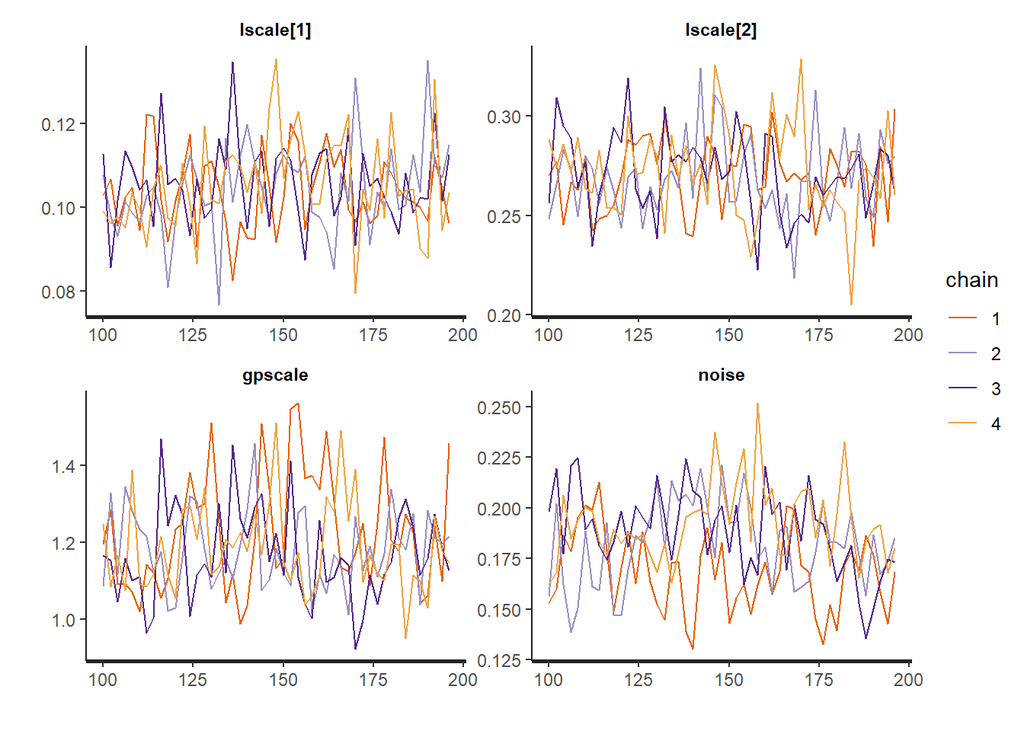

```r
traceplot(fit[[i]], pars = param, include = TRUE, unconstrain = FALSE, inc_warmup = FALSE, window = NULL, nrow = NULL, ncol = NULL)
```

### 6.4.5 Model evaluation

Root mean square error `rmse`, Bayesian $R^2$ (Coefficient of determination) `eR`, and expected log predictive density `elpd`.

```r
f_hsgp <- summary(fit[[i]], pars = c("f"), probs = c(0.025, 0.5, 0.975), digits_summary = 4)$summary[,c(1,4,6)]

# rmse against data
residual <- standata[[i]]$y_pred[vv_sample] - f_hsgp[,1]
rmse[i] <- round(sqrt(mean(residual^2)), 2)

# rmse against gp
residual_gp <- f_gp[vv_sample] - f_hsgp[,1]
rmse_gp[i] <- round(sqrt(mean(residual_gp^2)), 2)

# Coefficient of determination R^2
noise <- as.matrix(fit[[i]], pars = c("noise"))
sd_f <- apply(as.matrix(fit[[i]], pars = c("f")), 1, sd)
eR[i] <- round(median(sd_f^2/(sd_f^2 + noise^2)), 2)

# elpd
elpd[i] <- round(median(summary(fit[[i]], pars = c("elpd"))$summary[,1]), 2)
```

### 6.4.6 Diagnosis

Lengthscale estimate $\hat{\ell_i}$ in the HSGP approximation

```r
l_hat1[i] <- round(summary(fit[[i]], pars = "lscale[1]", probs = c(0.05, 0.95))$summary[,1], 2)
l_hat2[i] <- round(summary(fit[[i]], pars = "lscale[2]", probs = c(0.05, 0.95))$summary[,1], 2)
```

Check the diagnostic of whether $\, \hat{\ell_i} + 0.01 \geq \ell_i$

```r
check1[i] <- diagnostic(l1[i], l_hat1[i])
check2[i] <- diagnostic(l2[i], l_hat2[i])
```

Summary table of diagnosis

```r
diagnosis[[i]] <- data.frame(iter= c(i, i),
                              Dim= c("D1", "D2"),
                              l= c(l1[i], l2[i]),
                              c= c(c1[i], c2[i]),
                              m= c(m1[i], m2[i]),
                              l_hat= c(l_hat1[i], l_hat2[i]),
                              'l_hat > l' = c(check1[i], check2[i]),
                              rsme_gp = c(NA, rmse_gp[i]),
                              rsme = c(NA, rmse[i]),
                              R2 = c(NA, eR[i]),
                              elpd = c(NA, elpd[i]))
names(diagnosis[[i]]) <- c("iter", "Dim", "l", "c", "m", "l_hat", "l_hat + 0.01 > l", "rmse_gp", "rmse", "R^2", "elpd")

if(i==1){
  diagnosis[[i]]
}else{
  diagnosis[[i]] <- rbind(diagnosis[[i-1]],diagnosis[[i]])
  diagnosis[[i]]
}
```

| iter | Dim | l | c | m | l_hat | l_hat + 0.01 > l | rmse_gp | rmse | R^2 | elpd |
| --- | --- | --- | --- | --- | --- | --- | --- | --- | --- | --- |
| 1 | D1 | 0.500 | 1.6 | 6 | 0.190 | FALSE | NA | NA | NA | NA |
| 1 | D2 | 1.000 | 3.2 | 6 | 0.250 | FALSE | 0.72 | 0.75 | 0.46 | -0.96 |
| 2 | D1 | 0.190 | 1.2 | 12 | 0.107 | FALSE | NA | NA | NA | NA |
| 2 | D2 | 0.250 | 1.2 | 9 | 0.253 | TRUE | 0.12 | 0.18 | 0.94 | 0.04 |
| 3 | D1 | 0.107 | 1.2 | 20 | 0.100 | TRUE | NA | NA | NA | NA |
| 3 | D2 | 0.191 | 1.2 | 11 | 0.270 | TRUE | 0.03 | 0.11 | 0.97 | 0.31 |
| 4 | D1 | 0.095 | 1.2 | 22 | 0.110 | TRUE | NA | NA | NA | NA |
| 4 | D2 | 0.191 | 1.2 | 11 | 0.270 | TRUE | 0.02 | 0.10 | 0.97 | 0.34 |